# MSBMI 33200: Lecture 1

Anoop Mayampurath

October 7, 2019

## This course:

- Explains the inner workings of different machine learning (ML) models
- Considers applications of prediction models to biomedical data
- Follows the thinking behind MSBMI 32000: Intermediate Data Analysis

## Syllabus

## Refresher:

The objective of ML is to learn the function $f$ in

$$y = f(X)$$

## Refresher: Terminology

- Variables/Features/Predictors all refer to columns of the data matrix $X$
- Samples/Data Points all refer to rows in the rows in the data matrix $X$
- Outcome/response/labels all refer to elements in $y$
- Model parameters/weights/coefficients refer to $f$

## Refresher

In prediction studies, we train:

1. We estimate model weights from our dataset (called as fitting the data)

And we test:

1. We use model coefficients (from our original dataset, referred to as training dataset)
2. We use new data (referred to as test dataset)

## Refresher: Model types

- Regression, vs.
- Classification

## Model performace (Regression Models)

- Regression models: We look at mean residual errors, $R^2$ etc. between the predicted response and actual response in the test dataset
- We try to answer the question: how close are the predictions to the actual outcome?

## Model performance (Classification Models)

- Classification models: We look at predicted probabilities.
- To determine how close the pedictions are to the actual outcome, we use the Brier score.

## Brier Score

$$B = \frac{1}{n} \sum_{i=1}^{n}(Y - P(Y=1))^2$$

or

$$B = \frac{1}{n} \sum_{i=1}^{n}(Y - p)^2$$

Brier Score scaled:

$$B_{scaled} = 1 - \frac{B}{B_{max}}$$
, where

$$B_{max} = mean(p)*(1 - mean(p))$$

## Confusion Matrix

- Used to answer discrimination: do patients who have the outcome have higher risk predictions than those who don’t?

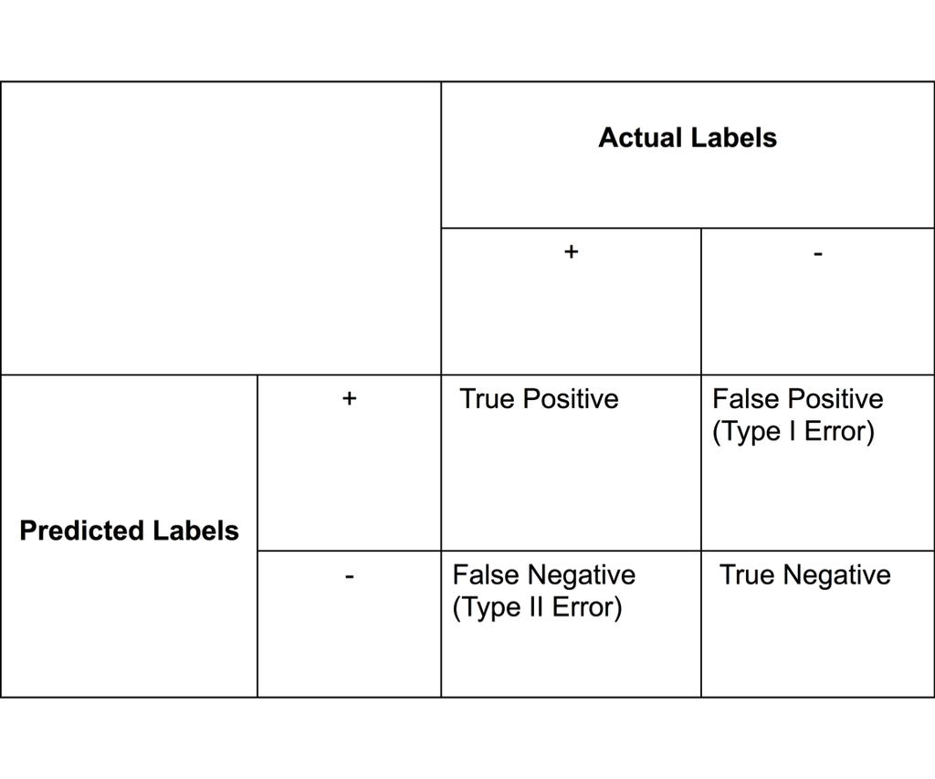

## Confusion Matrix (contd.)

$$\textit{Sensitivity} = \frac{TP}{(TP+FN)}$$

$$\textit{Specificity} = \frac{TN}{(FP+TN)}$$
$$\textit{Accuracy} = \frac{(TP+TN)}{(TP+FP+FN+TN)}$$

## ROC and AUC

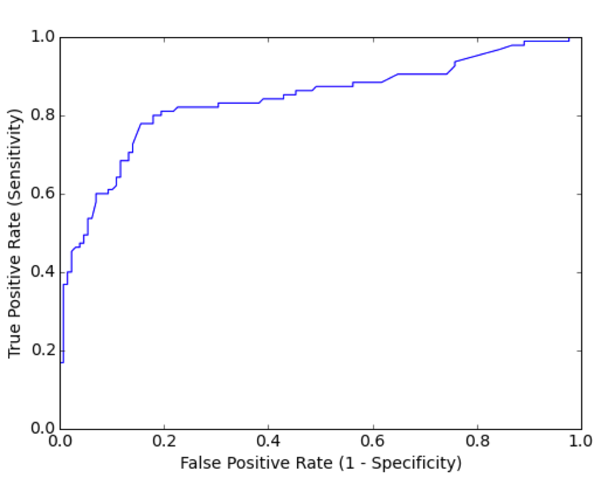

## ROC and AUC (contd)

- Plot of TPR (Sensitivity) and FPR (1-Specificity) for different probability cutoffs
- A diagonal line denotes a non-informative model with random predictions. A (0, 1) line indicates perfect predictions.
- Area under the ROC is called the AUC
- AUC of 0.5 denotes a non-informative model with random predictions. AUC of 1.0 indicates perfect predictions.
- For binary outcomes, AUC is similar to the concordance (c) statistic

## Youden’s Index

- Indicates the probability cutoff on the point of the ROC farthest from no-discrimination. This indicates maximum effectiveness of using the prediction model.
- Typically calculated as the point corresponding to max(senstivity + specificity - 1)
- All other metrics can be calculated from this cut-point.
- Can be done in pROC (https://rdrr.io/cran/pROC/man/coords.html)

## Model Calibration

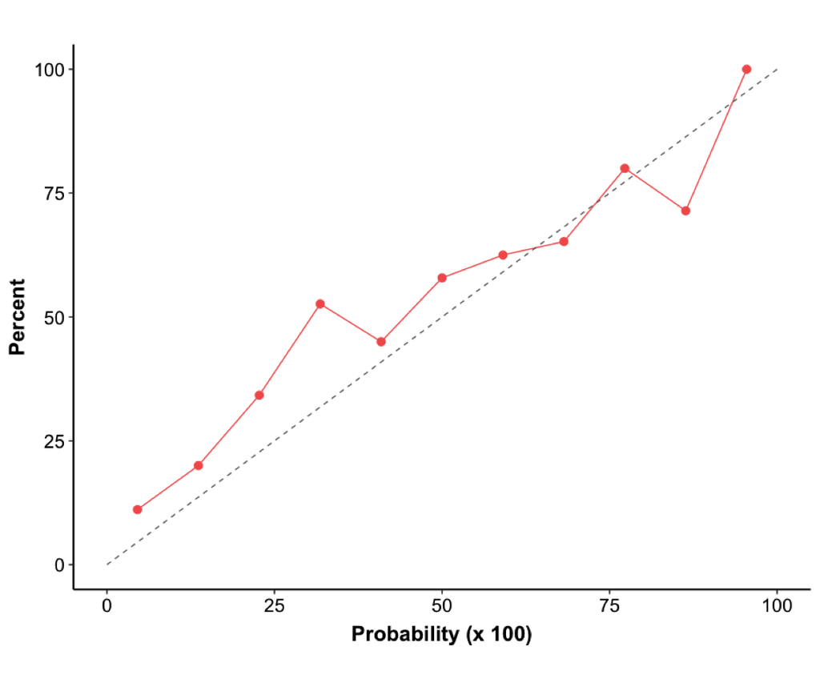

## Model Calibration

- Indicates level of agreement between predicted probabilities and outcome. In an ideal world, this would be a 1:1 mapping.
- Done though a plot with predictions on the X-axis and proportion of patients with outcome on the Y-axis.

## Break

## Recall: Bias-Variance tradeoff

$$\textit{Test_Error} \approx \textit{Var(Model)} + \textit{Bias (Model)}$$

Var(Model): amount by which model coefficients would change if we used different training data

Bias(Model): inherent error that comes from approximating real-world data

- As models get more flexible, variance increases, since small changes in training data will cause huge changes in the function $f()$. Take a cubic spline for example. A change in a single data point within the training data will result in a completely different spline. In contrast, a linear fit (i.e. using linear regression) will not be affected drastically with a changes in training data.
- As models get more flexible, bias decreases. In linear regression, we are making a linear assumption. No matter how much training data we have, we will not be able to capture any true non-linearity with linear regression. This results in high bias.

## ML Tip 1: Turn it on

- Work with the mindset that your model will be turned on at some point.
- Get only usable features.
- Get actionable outcomes.

## ML Tip 2: Follow good ML practics

- Division of dataset into independent derivation and validation cohorts
- Perform cross-validation to optimally chose your training parameters
- Use predicted probabilities instead of class labels
- Look at 95% CI for AUC. Remember that as $n$ increases, the 95%CI gets tighter.

## ML Tip 3: Go deep

- Understand ALL the features that are going into your model.
- Look for model fidelity in different sub-groups of samples.
- Do your best to interpret models.